# Titanic: Survival Prediction

Carlos Silva

2020-01-30

## Introduction

In this competition, you’ll gain access to two similar datasets that include passenger information like name, age, gender, socio-economic class, etc. One dataset is titled `train.csv` and the other is titled `test.csv`.

Train.csv will contain the details of a subset of the passengers on board (891 to be exact) and importantly, will reveal whether they survived or not, also known as the “ground truth”.

The `test.csv` dataset contains similar information but does not disclose the “ground truth” for each passenger.

Using the patterns you find in the train.csv data, predict whether the other 418 passengers on board (found in test.csv) survived.

## Loading Packages

```r
library("tidyverse")
library("caret")
```

## Loading and Preparing Data

```r
test <- read.csv('test.csv', stringsAsFactors = FALSE)
train <- read.csv('train.csv', stringsAsFactors = FALSE)
```

Let’s take a quick look at the data.

```r
glimpse(train)
```

```
## Observations: 891
## Variables: 12
## $ PassengerId <int> 1, 2, 3, 4, 5, 6, 7, 8, 9, 10, 11, 12, 13, 14, 15, 16, ...
## $ Survived    <int> 0, 1, 1, 1, 0, 0, 0, 0, 1, 1, 1, 1, 0, 0, 0, 1, 0, 1, 0...
## $ Pclass      <int> 3, 1, 3, 1, 3, 3, 1, 3, 3, 2, 3, 1, 3, 3, 3, 2, 3, 2, 3...
## $ Name        <chr> "Braund, Mr. Owen Harris", "Cumings, Mrs. John Bradley ...
## $ Sex         <chr> "male", "female", "female", "female", "male", "male", "...
## $ Age         <dbl> 22, 38, 26, 35, 35, NA, 54, 2, 27, 14, 4, 58, 20, 39, 1...
## $ SibSp       <int> 1, 1, 0, 1, 0, 0, 0, 3, 0, 1, 1, 0, 0, 1, 0, 0, 4, 0, 1...
## $ Parch       <int> 0, 0, 0, 0, 0, 0, 0, 1, 2, 0, 1, 0, 0, 5, 0, 0, 1, 0, 0...
## $ Ticket      <chr> "A/5 21171", "PC 17599", "STON/O2. 3101282", "113803", ...
## $ Fare        <dbl> 7.2500, 71.2833, 7.9250, 53.1000, 8.0500, 8.4583, 51.86...
## $ Cabin       <chr> "", "C85", "", "C123", "", "", "E46", "", "", "", "G6",...
## $ Embarked    <chr> "S", "C", "S", "S", "S", "Q", "S", "S", "S", "C", "S", ...
```

```r
glimpse(test)
```

```
## Observations: 418
## Variables: 11
## $ PassengerId <int> 892, 893, 894, 895, 896, 897, 898, 899, 900, 901, 902, ...
## $ Pclass      <int> 3, 3, 2, 3, 3, 3, 3, 2, 3, 3, 3, 1, 1, 2, 1, 2, 2, 3, 3...
## $ Name        <chr> "Kelly, Mr. James", "Wilkes, Mrs. James (Ellen Needs)",...
## $ Sex         <chr> "male", "female", "male", "male", "female", "male", "fe...
## $ Age         <dbl> 34.5, 47.0, 62.0, 27.0, 22.0, 14.0, 30.0, 26.0, 18.0, 2...
## $ SibSp       <int> 0, 1, 0, 0, 1, 0, 0, 1, 0, 2, 0, 0, 1, 1, 1, 1, 0, 0, 1...
## $ Parch       <int> 0, 0, 0, 0, 1, 0, 0, 1, 0, 0, 0, 0, 0, 0, 0, 0, 0, 0, 0...
## $ Ticket      <chr> "330911", "363272", "240276", "315154", "3101298", "753...
## $ Fare        <dbl> 7.8292, 7.0000, 9.6875, 8.6625, 12.2875, 9.2250, 7.6292...
## $ Cabin       <chr> "", "", "", "", "", "", "", "", "", "", "", "", "B45", ...
## $ Embarked    <chr> "Q", "S", "Q", "S", "S", "S", "Q", "S", "C", "S", "S", ...
```

To see what proportion of people survived

```r
summarise(train, SurvivalRate = sum(Survived)/nrow(train)*100)
```

```
##   SurvivalRate
## 1     38.38384
```

The survival rate among the train set was 38.38%.

For pre-processing, let’s collect all the data together

```r
titanic <- full_join(train, test)
glimpse(titanic)
```

```
## Observations: 1,309
## Variables: 12
## $ PassengerId <int> 1, 2, 3, 4, 5, 6, 7, 8, 9, 10, 11, 12, 13, 14, 15, 16, ...
## $ Survived    <int> 0, 1, 1, 1, 0, 0, 0, 0, 1, 1, 1, 1, 0, 0, 0, 1, 0, 1, 0...
## $ Pclass      <int> 3, 1, 3, 1, 3, 3, 1, 3, 3, 2, 3, 1, 3, 3, 3, 2, 3, 2, 3...
## $ Name        <chr> "Braund, Mr. Owen Harris", "Cumings, Mrs. John Bradley ...
## $ Sex         <chr> "male", "female", "female", "female", "male", "male", "...
## $ Age         <dbl> 22, 38, 26, 35, 35, NA, 54, 2, 27, 14, 4, 58, 20, 39, 1...
## $ SibSp       <int> 1, 1, 0, 1, 0, 0, 0, 3, 0, 1, 1, 0, 0, 1, 0, 0, 4, 0, 1...
## $ Parch       <int> 0, 0, 0, 0, 0, 0, 0, 1, 2, 0, 1, 0, 0, 5, 0, 0, 1, 0, 0...
## $ Ticket      <chr> "A/5 21171", "PC 17599", "STON/O2. 3101282", "113803", ...
## $ Fare        <dbl> 7.2500, 71.2833, 7.9250, 53.1000, 8.0500, 8.4583, 51.86...
## $ Cabin       <chr> "", "C85", "", "C123", "", "", "E46", "", "", "", "G6",...
## $ Embarked    <chr> "S", "C", "S", "S", "S", "Q", "S", "S", "S", "C", "S", ...
```

Impute missing Age values in titanic data

```r
titanicPre <- titanic %>% select(-Ticket, -Name, -Cabin, -Embarked)
pre.proc <- preProcess(titanicPre, method = "bagImpute")
titanicPre <- predict(pre.proc, titanicPre)
titanic$Age <- titanicPre$Age
```

## Features

### Survived

The Survived variable is binary, either someone died or survived. Let’s make it a factor and give it each level a name so that it is more “readable”.

```r
library(forcats)
titanic <- titanic %>%
        mutate(Survived = factor(Survived)) %>%
        mutate(Survived = fct_recode(Survived, "No" = "0", "Yes" = "1"))
```

### Sex

Let’s recode Sex into a factor variable, tidying up the labels and then add a proportional bar plot to examine survival by Sex.

```r
titanic <- titanic %>%
        mutate(Sex = factor(Sex)) %>%
        mutate(Sex = fct_recode(Sex, "Female" = "female", "Male" = "male"))
```

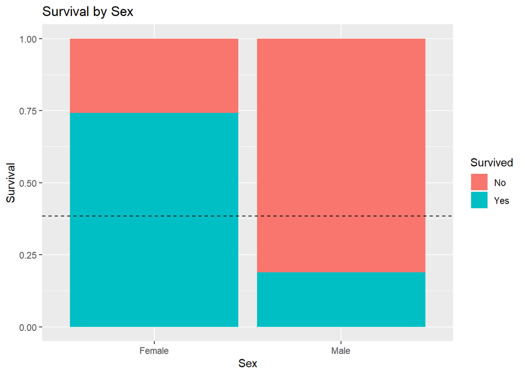

```r
ggplot(titanic[1:891,], aes(Sex, fill=Survived)) +
        geom_bar(position = "fill") +
        ylab("Survival") +
        geom_hline(yintercept = (sum(train$Survived)/nrow(train)), col = "black", lty = 2) +
        ggtitle("Survival by Sex")
```

In this bar plot we can see that women were over three times more likely to survive than men.

### Title

Now let’s extract the Title from passenger names and count them.

```r
titanic <- mutate(titanic, Title = str_sub(Name, str_locate(Name, ",")[ , 1] + 2, str_locate(Name, "\\.")[ , 1] - 1))

titanic %>%
        count(Title, sort = TRUE)
```

```
## # A tibble: 18 x 2
##    Title            n
##    <chr>        <int>
##  1 Mr             757
##  2 Miss           260
##  3 Mrs            197
##  4 Master          61
##  5 Dr               8
##  6 Rev              8
##  7 Col              4
##  8 Major            2
##  9 Mlle             2
## 10 Ms               2
## 11 Capt             1
## 12 Don              1
## 13 Dona             1
## 14 Jonkheer         1
## 15 Lady             1
## 16 Mme              1
## 17 Sir              1
## 18 the Countess     1
```

Convert title with low count into new title and count again

```r
titanic <- titanic %>%
        mutate(Title = factor(Title)) %>%
        mutate(Title = fct_collapse(Title, "Miss" = c("Mlle", "Ms"), "Mrs" = c("Mme", "the Countess"),
                                    "Mr" = c( "Major", "Capt", "Col", "Rev", "Don", "Jonkheer"), "Other" = c("Lady", "Dr", "Sir", "Dona")
        ))

titanic %>%
        count(Title, sort = TRUE)
```

```
## # A tibble: 5 x 2
##   Title      n
##   <fct>  <int>
## 1 Mr       774
## 2 Miss     264
## 3 Mrs      199
## 4 Master    61
## 5 Other     11
```

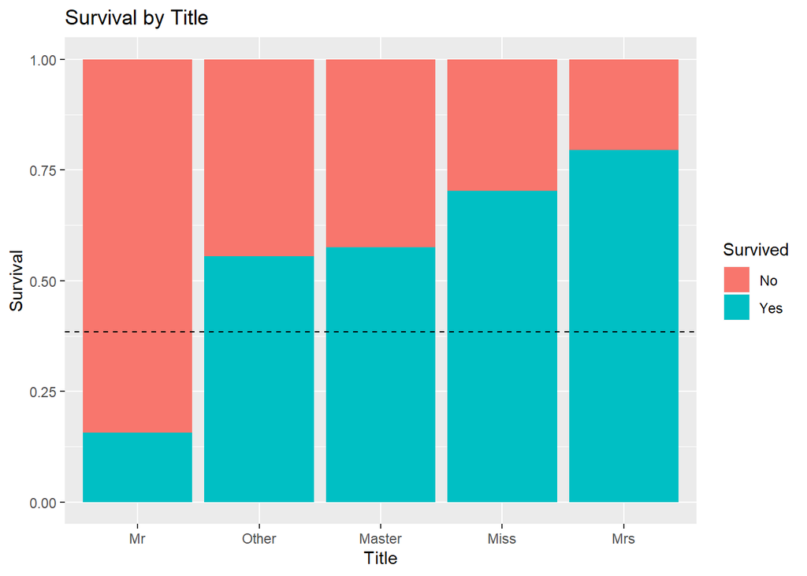

```r
ggplot(titanic[1:891,], aes(x = Title, fill = Survived)) +
        geom_bar(position = "fill") +
        ylab("Survival") +
        geom_hline(yintercept = (sum(train$Survived)/nrow(train)), col = "black", lty = 2) +
        ggtitle("Survival by Title")
```

Only the Mr group had worse than average survival chances.

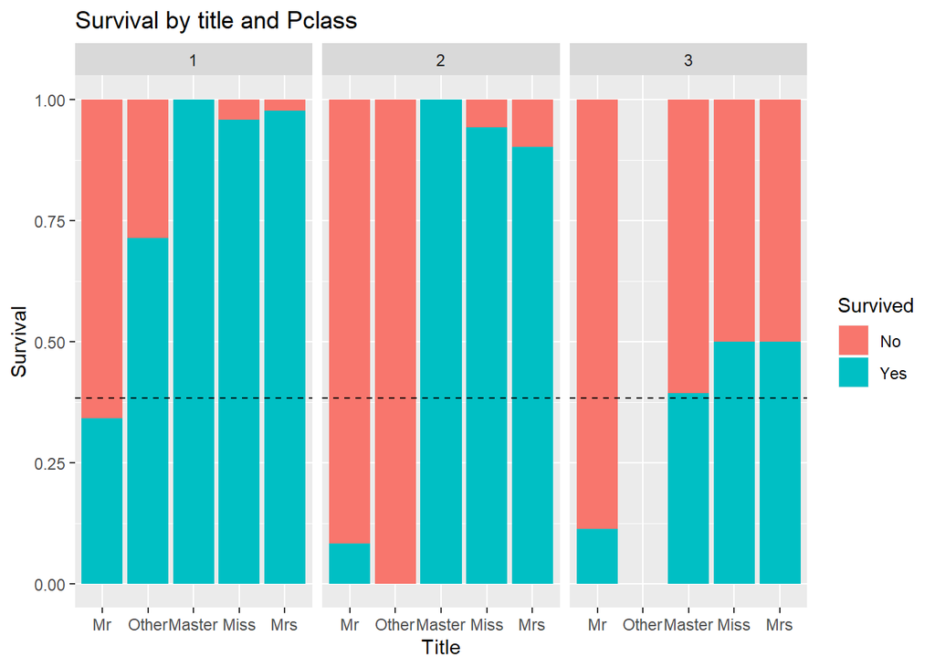

```r
ggplot(titanic[1:891,], aes(x=Title, fill=Survived)) +
        geom_bar(position = "fill") +
        ylab("Survival") +
        geom_hline(yintercept = (sum(train$Survived)/nrow(train)), col = "black", lty = 2) +
        ggtitle("Survival by title and Pclass") +
        facet_wrap(~ Pclass)
```

the Mr group had worse survival chances in all passenger classes.

### Family size

Now let’s combine SibSp and Parch into a single “family size” variable, and define a large family as one that has more than 4 people, a small family as one that has more than 1 but fewer than 5 and single people as 1.

```r
titanic <- titanic %>%
        mutate(Family = SibSp + Parch + 1) %>%
        mutate(FamilySize = factor(ifelse(Family > 4, "Large", ifelse(Family == 1, "Single", "Small"))))

titanic %>%
        count(FamilySize, sort = TRUE)
```

```
## # A tibble: 3 x 2
##   FamilySize     n
##   <fct>      <int>
## 1 Single       790
## 2 Small        437
## 3 Large         82
```

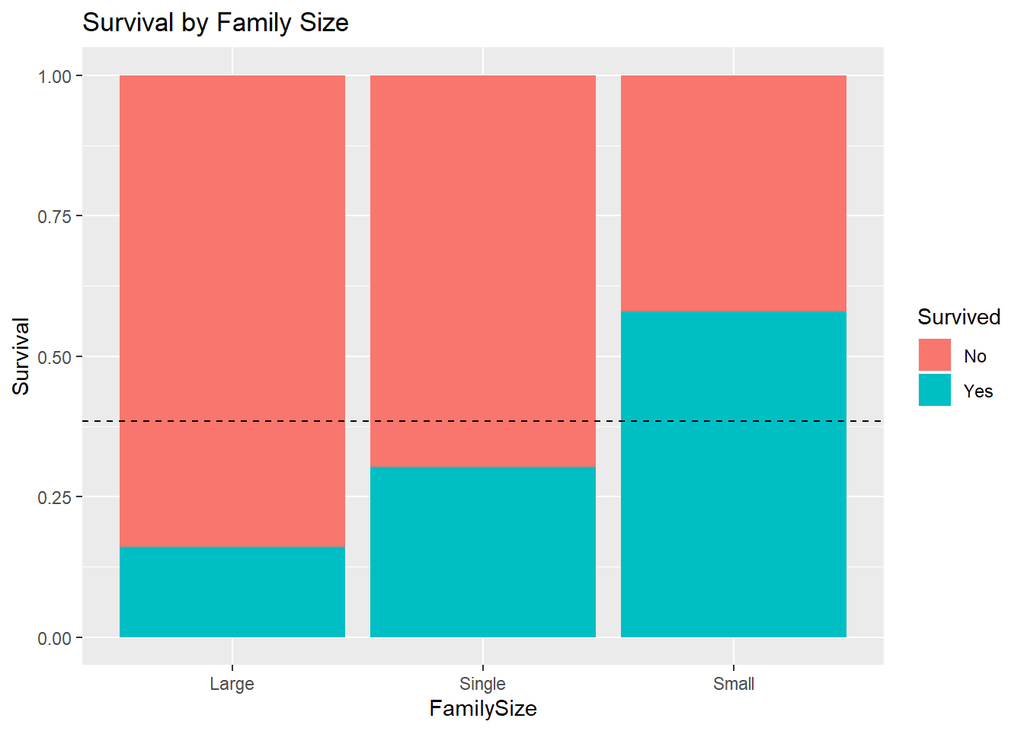

```r
ggplot(titanic[1:891,], aes(x = FamilySize, fill = Survived)) +
        geom_bar(position = "fill") +
        ylab("Survival") +
        geom_hline(yintercept = (sum(train$Survived)/nrow(train)), col = "black", lty = 2) +
        ggtitle ("Survival by Family Size")
```

we can see that was easier to organize and save the familys that had a small size.

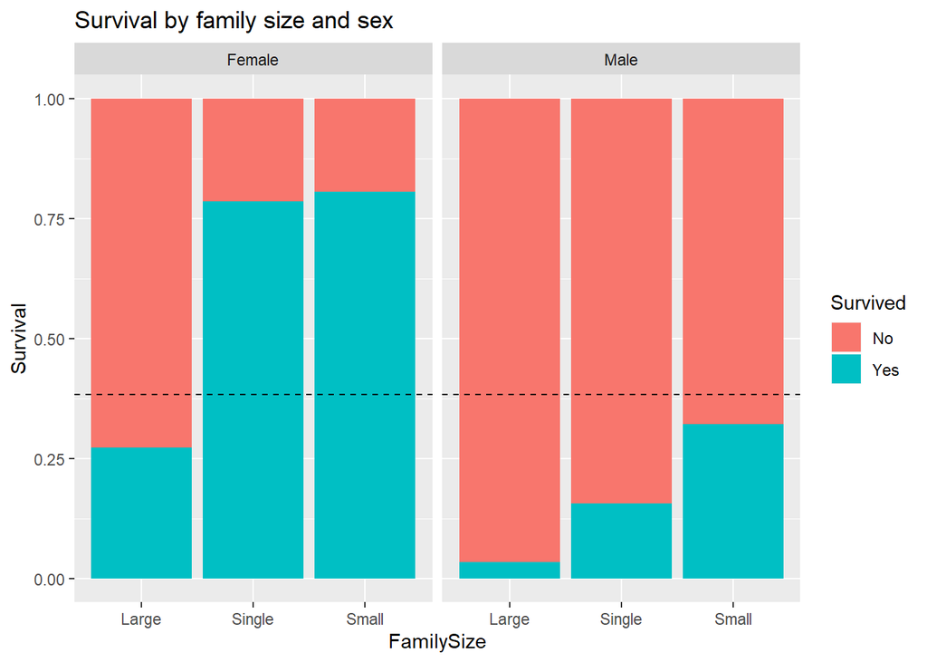

```r
ggplot(titanic[1:891,], aes(x = FamilySize, fill = Survived)) +
        geom_bar(position = "fill") +
        ylab("Survival") +
        geom_hline(yintercept = (sum(train$Survived)/nrow(train)), col = "black", lty = 2) +
        ggtitle ("Survival by family size and sex") + facet_wrap(~ Sex)
```

The man with a large family had worse survival chances.

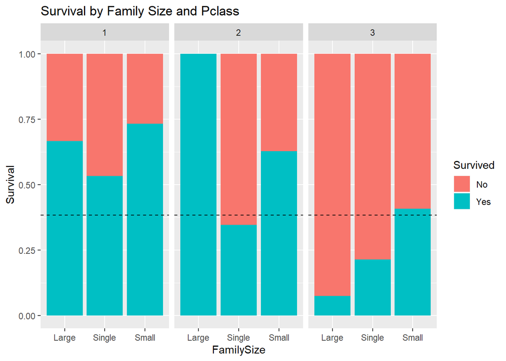

```r
ggplot(titanic[1:891,], aes(x = FamilySize, fill = Survived)) +
        geom_bar(position = "fill") +
        ylab("Survival") +
        geom_hline(yintercept = (sum(train$Survived)/nrow(train)), col = "black", lty = 2) +
        ggtitle ("Survival by Family Size and Pclass") + facet_wrap(~ Pclass)
```

All family sizes from the 1st class had better than a 50/50 chance to survive.

### Embarked

Let’s see where the passengers embarked and transform the missing values into NA

```r
titanic %>%
        count(Embarked, sort = TRUE)
```

```
## # A tibble: 4 x 2
##   Embarked     n
##   <chr>    <int>
## 1 "S"        914
## 2 "C"        270
## 3 "Q"        123
## 4 ""           2
```

```r
titanic$Embarked[titanic$Embarked == ""] <- NA

titanic %>%
        filter(is.na(Embarked))
```

```
##   PassengerId Survived Pclass                                      Name    Sex
## 1          62      Yes      1                       Icard, Miss. Amelie Female
## 2         830      Yes      1 Stone, Mrs. George Nelson (Martha Evelyn) Female
##   Age SibSp Parch Ticket Fare Cabin Embarked Title Family FamilySize
## 1  38     0     0 113572   80   B28     <NA>  Miss      1     Single
## 2  62     0     0 113572   80   B28     <NA>   Mrs      1     Single
```

Both passengers 62 and 830 had first class tickets and spend 80, let’s see the embarkment ports of others who bought similar kinds of tickets

```r
titanic %>%
        group_by(Embarked, Pclass) %>%
        filter(Pclass == "1") %>%
        summarise(mFare = median(Fare), n = n())
```

```
## # A tibble: 4 x 4
## # Groups:   Embarked [4]
##   Embarked Pclass mFare     n
##   <chr>     <int> <dbl> <int>
## 1 C             1  76.7   141
## 2 Q             1  90       3
## 3 S             1  52     177
## 4 <NA>          1  80       2
```

```r
titanic$Embarked[c(62, 830)] <- 'C'
```

Looks like the median price for a first class ticket departing from ‘C’ (Charbourg) was 77, very similar to the value that passangers 62 and 830 spend (80), so i replace the NA values with ‘C’.

Now let’s recode Embarked into a factor variable

```r
titanic <- titanic %>%
        mutate(Embarked = factor(Embarked))
```

Let’s tale a quick look at how embarkation ports relate to survival chances

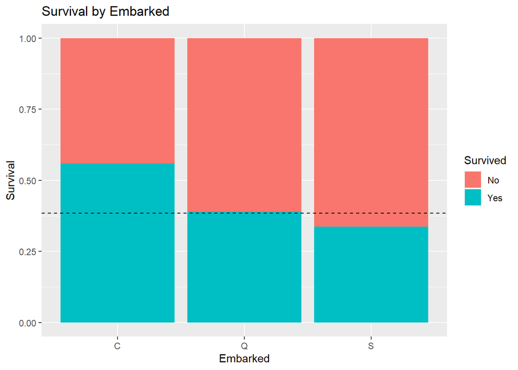

```r
ggplot(titanic[1:891,], aes(x = Embarked, fill = Survived)) +
        geom_bar(position = "fill") +
        ylab("Survival") +
        geom_hline(yintercept = (sum(train$Survived)/nrow(train)), col = "black", lty = 2) +
        ggtitle("Survival by Embarked")
```

The Cherbourg passengers appear to have had the better chances.